# R Coding Lab Part 1

# 3DS : Cherry Blossom

## Lyuda Bekwinknoll, Meghana Cyanam, Theresa Marie Duenas, Kevin Kiser

**Complete the following lab as a group. This document should exist in your GitHub repo while you’re working on it. Your code should be heavily commented so someone reading your code can follow along easily. See the first code snippet below for an example of commented code.**

**Here’s the catch: For any given problem, the person writing the code should not be the person commenting that code, and every person must both code AND comment at least one problem in this lab (you decide how to split the work). This will involve lots of pushing and pulling through Git, and you may have to resolve conflicts if you’re not careful! Refer to last Thursday’s class notes for details on conflict resolution.**

**Use only tools covered in our lectures**.

# Question 1

### Playing With Cherry Blossom Race Data

1. First load the data, which is saved as a .RData file called `CBdata.1_10.RData`. This is the first ten years’ worth of Cherry Blossom Race data. Pull out the data associated with 1976 and store it as a data frame called `dat.76`. Remove the column `Pis/Tis`.

```r
# load cherry blossom data
load("CBdata.1_10.RData")

# select table 4 data (data from year 1976)
CBdata.1_10[[4]] -> dat.76


# remove Pis/Tis column
dat.76 <- dat.76[,-6]
dat.76
```

# Question 2

2. The function `summary()` is useful for learning basic facts about vectors, data frames, and many other R objects. Use this function to find the mean and median recorded ages in 1976.

```r
# dat.76 summary
summary(dat.76)
```

```
##      Race               Name                Age            Time
##  Length:942         Length:942         Min.   : 6.00   Length:942
##  Class :character   Class :character   1st Qu.:26.00   Class :character
##  Mode  :character   Mode  :character   Median :32.00   Mode  :character
##                                        Mean   :32.09
##                                        3rd Qu.:39.00
##                                        Max.   :73.00
##                                        NA's   :461
##      Pace             Division           PiD/TiD            Hometown
##  Length:942         Length:942         Length:942         Length:942
##  Class :character   Class :character   Class :character   Class :character
##  Mode  :character   Mode  :character   Mode  :character   Mode  :character
##
##
##
##
##       Year
##  Min.   :1976
##  1st Qu.:1976
##  Median :1976
##  Mean   :1976
##  3rd Qu.:1976
##  Max.   :1976
##
```

**The mean recorded age for 1976 is 32.09. The median recorded age for 1976 is 32.**

# Question 3

3. You might have noticed that a number of age values are missing (i.e. `NA`). Your next goal is to write a loop that removes observations that don’t have age data.  
   Hints:
- The `is.na()` function may be useful. Use the `?is.na` command to pull up documentation on this function. It might be helpful to play around with a toy example like `c(1,2,NA,3)` to make sure you understand this new function!
- Depending on how you write your code, you may need to negate a logical vector using `!`. Ex: `!c(TRUE, TRUE, FALSE)` is identical to `c(FALSE, FALSE, TRUE)`.

```r
# new variable data into data frame
dat.76.clean = as.data.frame(matrix(ncol=9))
# make column names of new variable equal to dat.76
colnames(dat.76.clean) <- colnames(dat.76)
# sets first row equal between both data frames
dat.76.clean[1,] <- dat.76[1,]

# for loop removing NA age data
for (i in 2:dim(dat.76)[1])
  {
  if(is.na(dat.76$Age[i]) == FALSE) # selects data with NA age
    {
      dat.76.clean <- rbind(dat.76.clean,dat.76[i,] ) # removes data with NA age
    }

  }
```

# Question 4

4. Now use vectorization and the `is.na()` function to accomplish the same thing as the loop above.  
   How to check your work: If your loop produced a data frame called “dat.76.clean” and the vectorization approach produced a data frame called `dat.76.clean2`, the `identical(dat.76.clean,dat.76.clean2)` should return `TRUE`.

```r
# selects all the data that doesn't have NA in age
dat.76.clean2 <- dat.76[!is.na(dat.76$Age),]

# checks whether df's are identical
identical(dat.76.clean,dat.76.clean2)
```

```
## [1] TRUE
```

# Question 5

5. Filtering out missing age data could be useful when dealing with other years. With this in mind, turn your filter loop or vectorization approach into a function. You should be able to use the function like this: `dat.76.clean <- filter.func(dat.76)`.  
   When you have a function written, run it on the 1976 data and use identical() to verify that your function and the first loop you wrote are doing the same thing.

```r
# function with df as input
# returns a cleaned df
filter.func <- function(data) {
  # sets size of df the same as input
  clean_data <- as.data.frame(matrix(nrow = nrow(data), ncol = ncol(data)))
  # sets column names of df same as input
  colnames(clean_data) <- colnames(data)
  n <- 1
  # for loop to remove NA for age
  for (i in 1:nrow(data)) {
    # if Age is not NA, add the row to the new df
    if (!is.na(data$Age[i])) {
      clean_data[n, ] <- data[i, ]
      n <- n + 1
    }
  }
  # returns cleaned df
  return(clean_data[1:(n - 1), ])
}

# call function
dat.76.clean3 <- filter.func(dat.76)
# rename rows to sequential list of numbers
rownames(dat.76.clean3) <- c(1:481)
rownames(dat.76.clean) <- c(1:481)

# checks whether df's are identical
identical(dat.76.clean, dat.76.clean3)
```

```
## [1] TRUE
```

# Question 6

6. Next, write a loop that combines all of the data from `CBdata.1_10` into one cleaned data frame. Make sure your final data frame has neither the `Pis/Tis` column nor `NA` Age values.  
   Use the `identical()` function to verify that the 1976 data in this larger cleaned data set is the same as the cleaned version of `dat.76`.

```r
# creates an empty dataframe to store the cleaned data
CBdata.1_10.clean <- data.frame()

# loops through the df and gives cleaned df
for (i in 1:length(CBdata.1_10)) {

  current_df <- CBdata.1_10[[i]] # selects a df in the df
  current_df <- current_df[, -6] # removes Pis/Tis column

  # selects rows without NA age
  current_df <- current_df[!is.na(current_df$Age), ]
  # binds the cleaned out df into a large df
  CBdata.1_10.clean <- rbind(CBdata.1_10.clean, current_df)
}

# filters out 1976 and renames the rows to match
filtered_df <- subset(CBdata.1_10.clean, Year == "1976")
# sets rownames equal to eachoter
rownames(filtered_df) <- c(1:481)
rownames(dat.76.clean) <- c(1:481)

# return TRUE if dfs are identical
identical(dat.76.clean, filtered_df)
```

```
## [1] TRUE
```

# Question 7

7. Now that you have the combined data set for these 10 years, let’s do some basic exploration:
1. How does the average of the recorded ages in 1976 compare to that same average over the entire `CBdata.1_10` data set?
2. Recall that the `CBdata.1_10` contains the first ten year’s worth of cherry blossom race data. How does the average participant age over the first five years compare to the average age over years 6-10?

```r
# finds mean age of year 1976
mean_age_1976 <- mean(CBdata.1_10.clean$Age[CBdata.1_10.clean$Year == 1976])
# finds mean of age of all
mean_age_all <- mean(CBdata.1_10.clean$Age)

# runs the one sample t test
t_test_result <- t.test(
  x = CBdata.1_10.clean$Age[CBdata.1_10.clean$Year == 1976],
  mu = mean_age_all,
  alternative = "two.sided"
)

#prints out results
print(paste("mean age in 1976:", round(mean_age_1976, 2)))
```

```
## [1] "mean age in 1976: 32.09"
```

```r
print(paste("mean age of first 10 years:", round(mean_age_all, 2)))
```

```
## [1] "mean age of first 10 years: 33.26"
```

```r
print("T-test result:")
```

```
## [1] "T-test result:"
```

```r
print(t_test_result)
```

```
##
##  One Sample t-test
##
## data:  CBdata.1_10.clean$Age[CBdata.1_10.clean$Year == 1976]
## t = -2.2902, df = 480, p-value = 0.02244
## alternative hypothesis: true mean is not equal to 33.26157
## 95 percent confidence interval:
##  31.09142 33.09569
## sample estimates:
## mean of x
##  32.09356
```

To compare the mean age from 1976 to the mean age of the entire dataset (1973 to 1982), we ran one sample t-test (two-tailed). The null hypothesis (H0) posited that there is no significant difference in mean ages between the sample (1976) and the population mean (1973 to 1982), while the alternative hypothesis (H1) suggested the presence of a significant difference.

The analysis yielded a statistically significant result, with the p-value of .02244 falling below the chosen alpha level (0.05). Consequently, we reject the null hypothesis, providing strong evidence that a significant difference exists between the sample mean age, and the population mean age.

```r
# mean of years from 1973 to 1977
mean_age_73_77 <- mean(CBdata.1_10.clean$Age[CBdata.1_10.clean$Year
                                             %in% 1973:1977])
# mean of years from 1978 to 1982
mean_age_78_82 <- mean(CBdata.1_10.clean$Age[CBdata.1_10.clean$Year
                                             %in% 1978:1982])

# runs the two sample t test
t_test_result <- t.test(
  x = CBdata.1_10.clean$Age[CBdata.1_10.clean$Year %in% 1973:1977],
  y = CBdata.1_10.clean$Age[CBdata.1_10.clean$Year %in% 1978:1982],
  alternative = "two.sided"
)

# prints the results
print(paste("mean age of the first 5 years:", round(mean_age_73_77, 2)))
```

```
## [1] "mean age of the first 5 years: 31.12"
```

```r
print(paste("mean age of the next 5 years:", round(mean_age_78_82, 2)))
```

```
## [1] "mean age of the next 5 years: 33.69"
```

```r
print("T-test result:")
```

```
## [1] "T-test result:"
```

```r
print(t_test_result)
```

```
##
##  Welch Two Sample t-test
##
## data:  CBdata.1_10.clean$Age[CBdata.1_10.clean$Year %in% 1973:1977] and CBdata.1_10.clean$Age[CBdata.1_10.clean$Year %in% 1978:1982]
## t = -11.718, df = 3439, p-value < 2.2e-16
## alternative hypothesis: true difference in means is not equal to 0
## 95 percent confidence interval:
##  -3.002028 -2.141437
## sample estimates:
## mean of x mean of y
##  31.11927  33.69101
```

To compare the mean age from the first five years (1973-1977) to the mean age of the next five years (1978 to 1982) we ran a two sample t-test (two-tailed). The null hypothesis (H0) posited that there is no significant difference in mean ages between the two groups, while the alternative hypothesis (H1) suggested the presence of a significant difference.

The analysis yielded a statistically significant result, with the p-value of 2.2e-16 falling below the chosen alpha level (0.05). Consequently, we reject the null hypothesis, providing strong evidence that a significant difference exists in the mean ages of the two groups.

```r
library(dplyr)
```

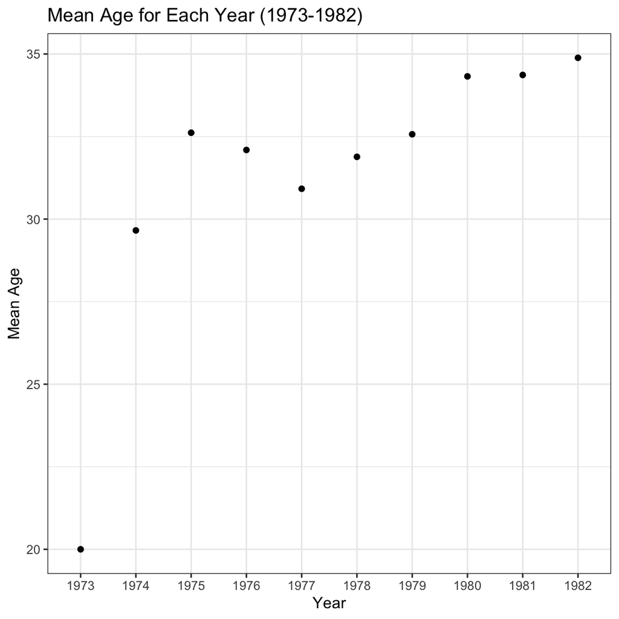

```r
library(ggplot2)

# finds the mean age by year
mean_age_by_year <- CBdata.1_10.clean %>%
  filter(Year >= 1973 & Year <= 1982) %>%
  group_by(Year) %>%
  summarize(mean_age = mean(Age))

# plots the mean age
ggplot(data = mean_age_by_year, aes(x = as.factor(Year), y = mean_age)) +
  geom_point() +
  labs(x = "Year", y = "Mean Age") +
  ggtitle("Mean Age for Each Year (1973-1982)") +
  scale_x_discrete(labels = c("1973", "1974", "1975", "1976", "1977", "1978", "1979", "1980", "1981", "1982")) +
  theme_bw()
```

The mean ages can also be compared visually by the plot shown above.